# Depopulation is a Geographical Phenomenon

Rachel Franklin (@rsfrankl)

Center for Geographic Analysis | Harvard University

2026-11-19

# Population loss is already a reality for many places and on the horizon for lots of others.

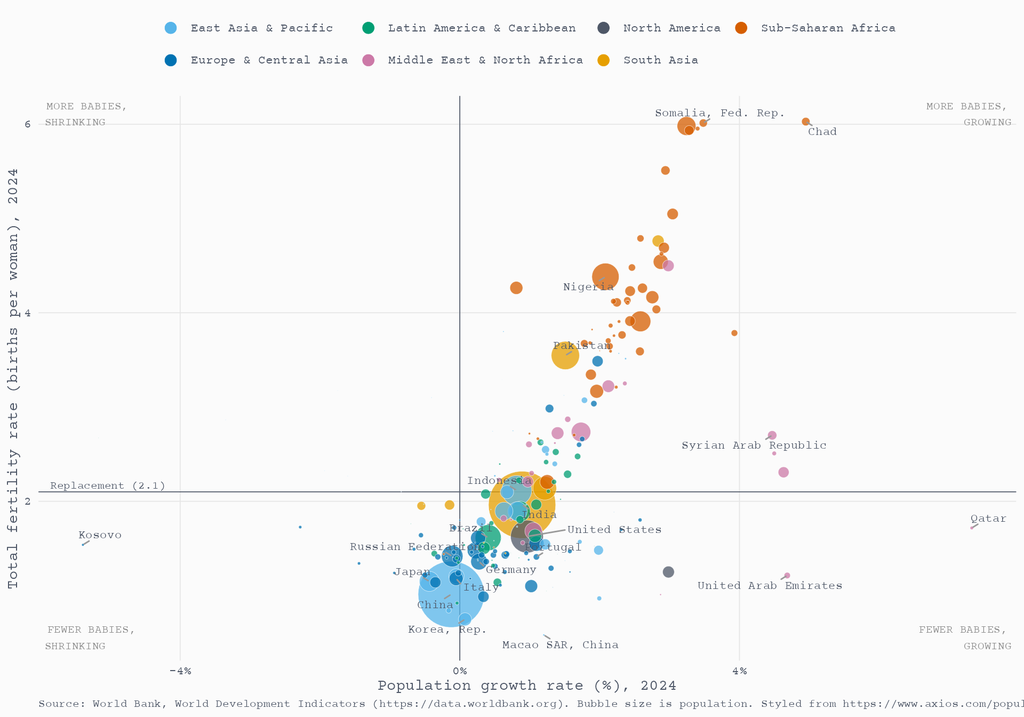

Global Total Fertility Rates and Population Growth Rates, 2024

# Why care?

## Known societal impacts, including

- Aging and labor market pressures
  - Who will work? Who will perform care duties?
- Economic and fiscal challenges
  - Who will pay taxes? Who will buy my house?
- Shifting population distribution
  - Will people in big cities understand my rural experience of loss?

## It’s also a collective experience

- How neighborhoods and cities look and feel
- Preferences around family formation and children
- Politics of immigration, ethnicity, and population growth
- Household wealth (housing)
- Experiential gaps between growing and shrinking areas

# The main premise of my talk is that we talk a lot about the demographic aspects of population loss. However, population loss is fundamentally *geographic*.

# The rest of this lecture

1. A quick overview of some key demographic aspects

2. Then a deep dive into the **geography** of population loss

# Demography (very important!)

## How we often think about the causes of population loss

- **Lack of opportunity** (people out-migrate, delay household formation)
- **Cost of living** (pressures to delay or forgo childbearing)
- Economic (and climate and political) **uncertainty**

## But of course the *proximate* sources of population loss are demographic

## Globally, there’s only one way to grow or shrink

## Natural change

Births  
Deaths

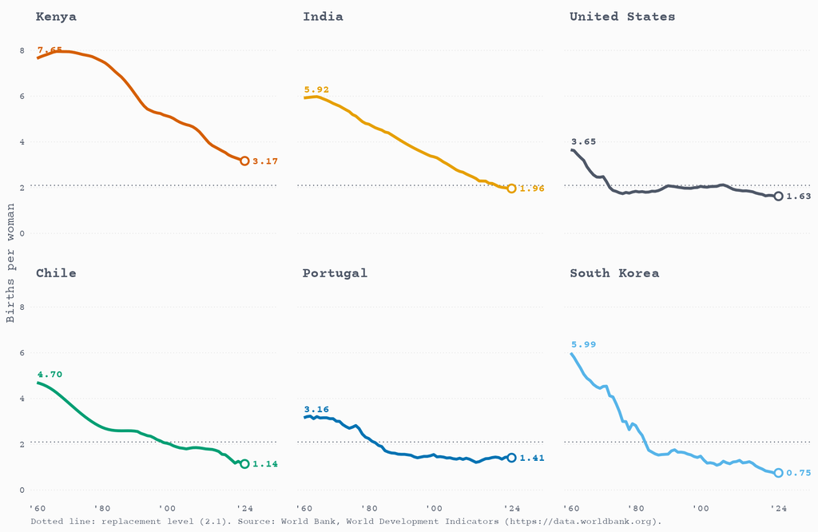

Total fertility rate, selected countries, 1960–2024

## For places migration really matters

People move in and out of areas selectively; some places see net in-migration while others experience net out-migration

- **Internal** (within an area, like a country)
- **International** (across international borders)
- With prevailing lower fertility rates, growth is fueled by attracting migrants
- Because migrants tend to be younger, when they leave, they take not only themselves (and their skills), they also take any future children they may have

## The importance of international migration should not be underestimated

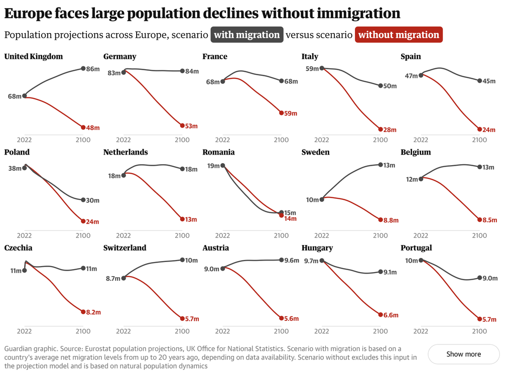

## Another demographic factor: ageing and age structure

- Lower fertility rates
- But also longer life expectancies (this is a good thing!)
- But creates lots of challenges

## And, of course, demographic composition evolves as depopulation occurs

# Now let’s talk about geography

# **Two** components to the *Depopulation is a Geographical Phenomenon* argument

## 1. How population loss plays out over space

and how this matters for cities, regions, and countries

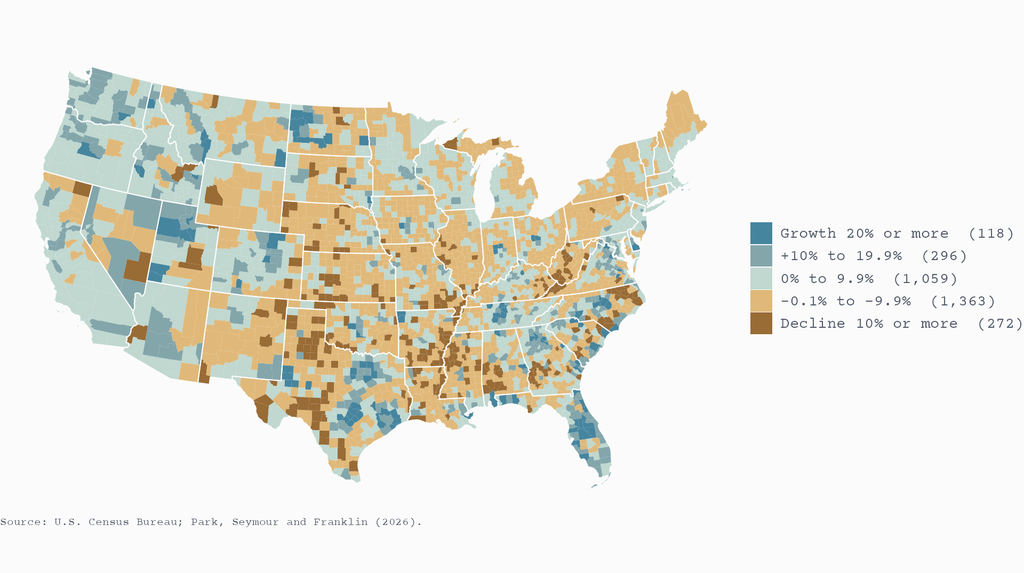

US county population change, 2010–2020

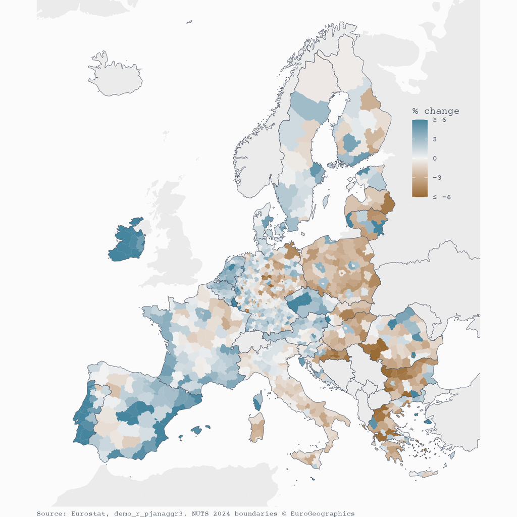

Population change by NUTS 3 region, 2021–2025

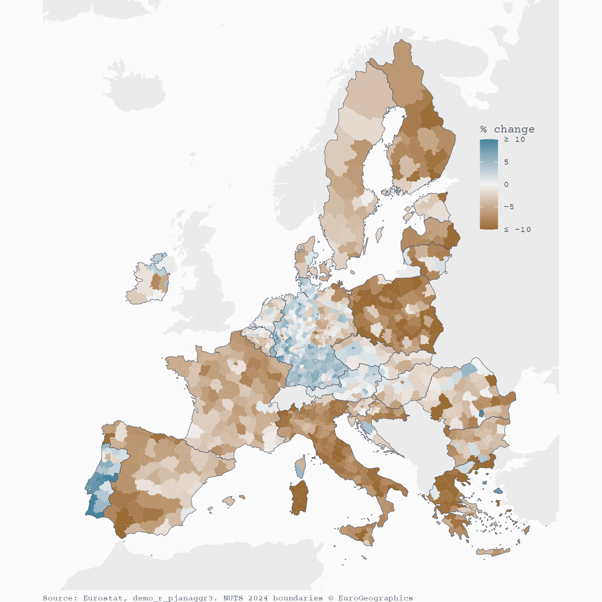

Under 15 population change by NUTS 3 region, 2021–2025

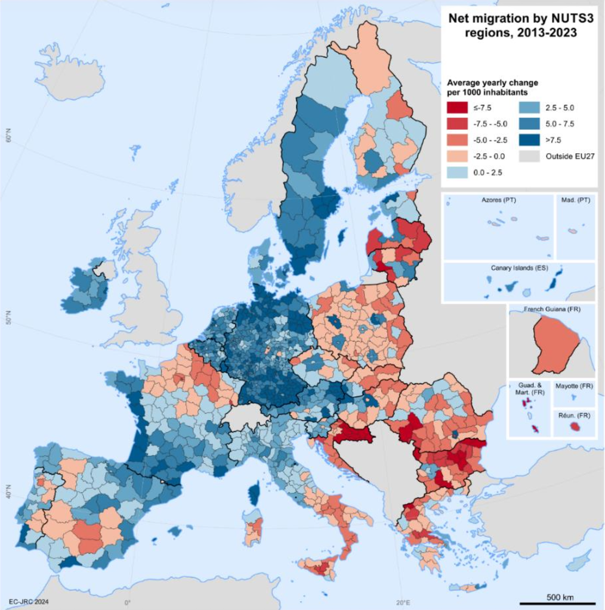

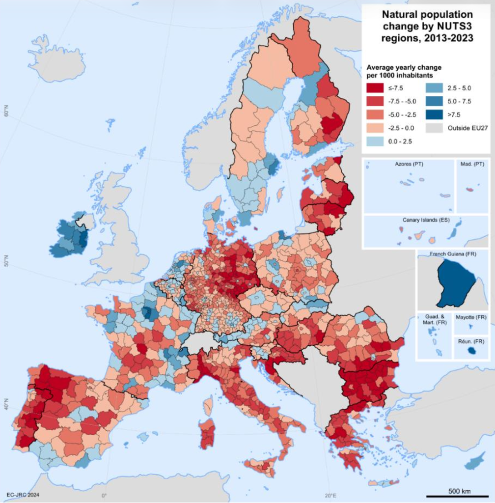

TESTORI, G., FRANKLIN, R., SARACENO, P., PERTOLDI, M., PEREA MILLA FERNANDEZ, D. et al., Territories and demographic change - Regional patterns and policy approaches, Publications Office of the European Union, Luxembourg, 2026, https://data.europa.eu/doi/10.2760/4140574, JRC143332.

## 2. How does geography inform the *measurement* of population change and understanding of how it’s experienced?

## An incomplete list (in progress!)

- Scale
- Context
- Clustering
- Fragmentation
- Centrality / Peripherality
- The urban-rural continuum

## Scale

The choice of units will change our estimates of *where* is shrinking. But also choice of unit should match conceptual expectations of drivers and impacts of loss.

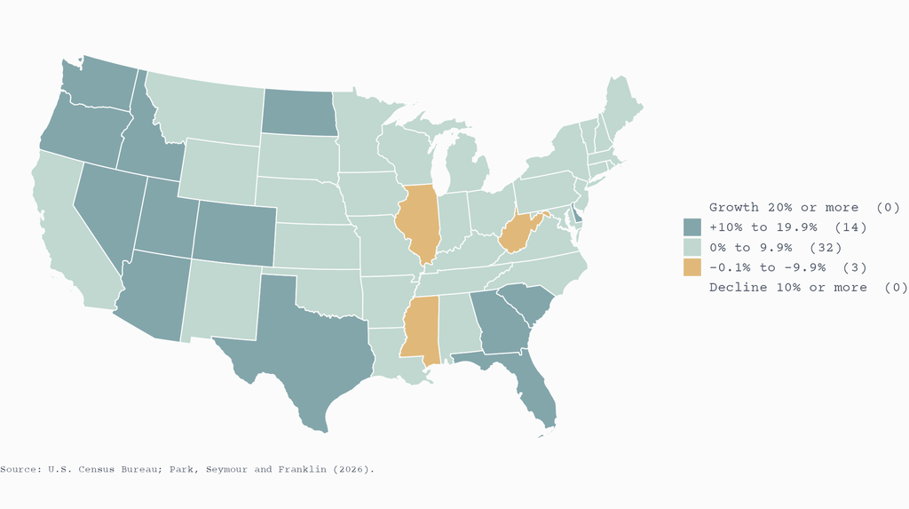

State population change, 2010–2020

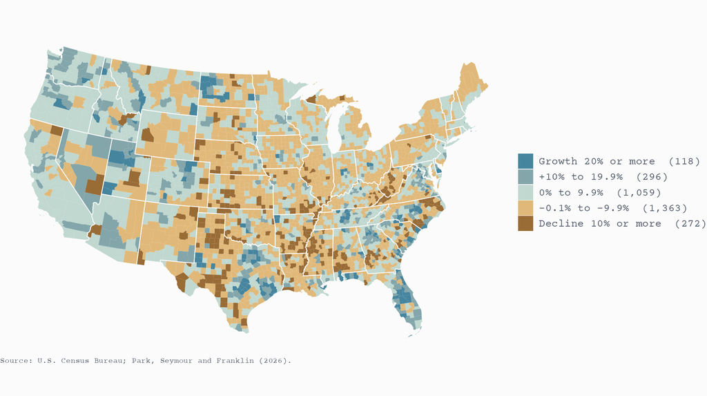

County population change, 2010–2020

## Scale

But even same types of units aren’t always comparable

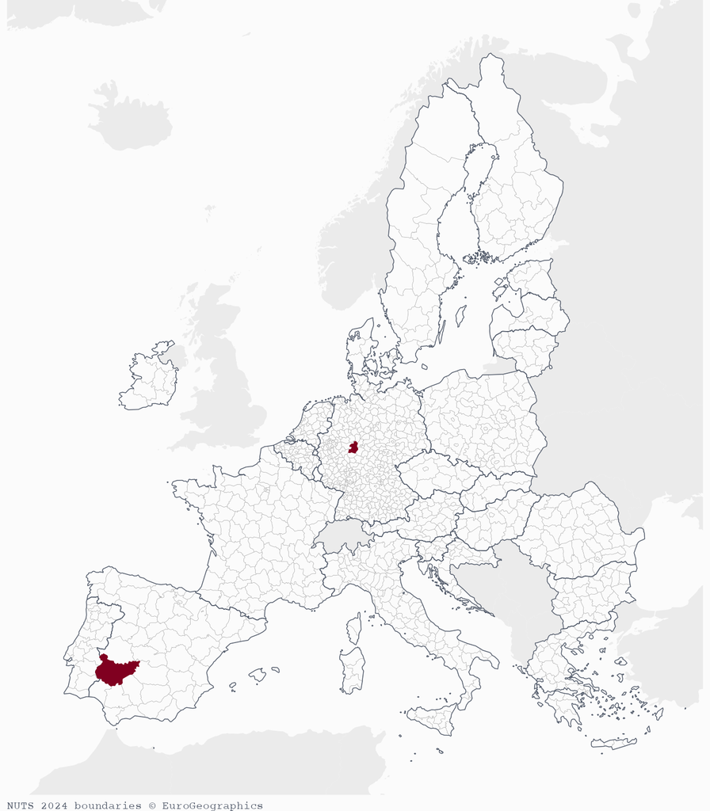

These are both NUTS 3 regions

## Context

It also matters what’s happening *around* a particular area, whether city, region, or neighborhood

[figure not shown]

## In the US both growth and decline are largely embedded

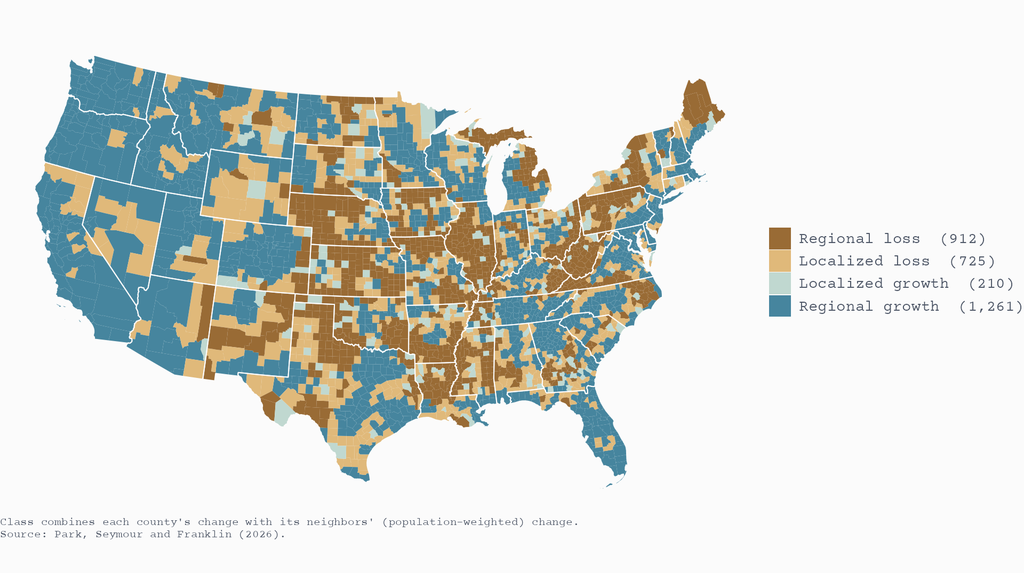

US county-level population change in spatial context, 2010–2020

## Clustering

When an area is losing population, how evenly distributed is the loss? Are shrinking areas close to other shrinking areas?

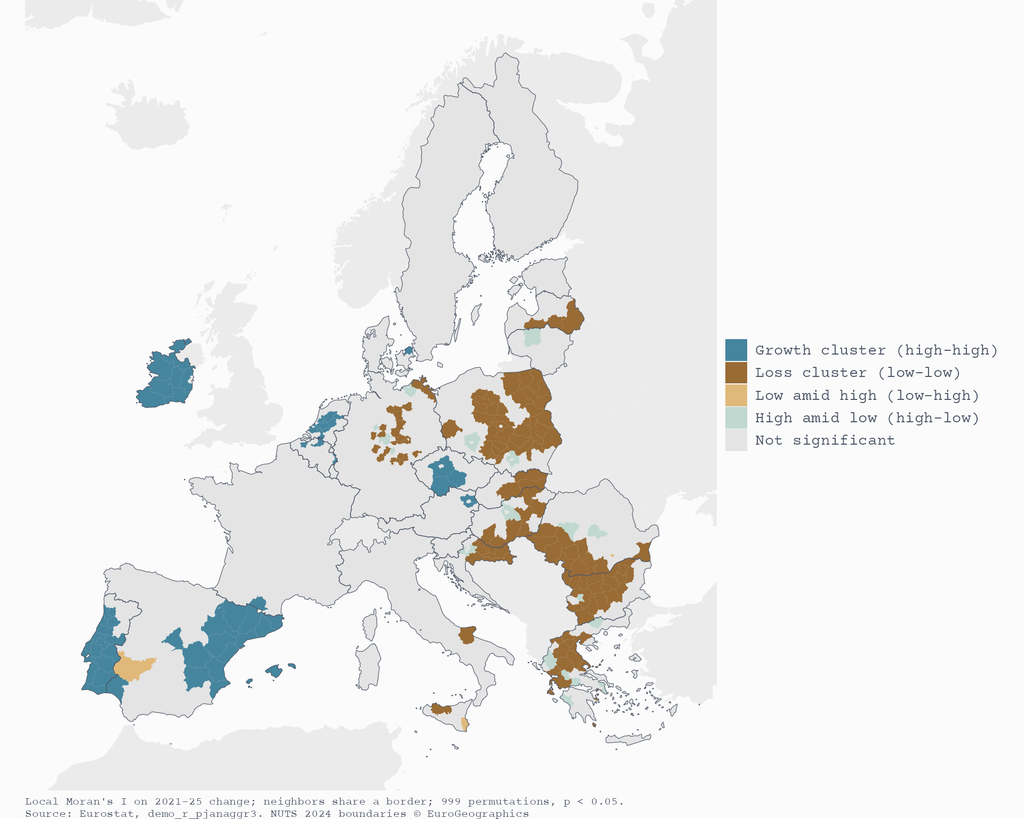

Local Moran’s I map of population change, NUTS 3 regions, 2021–2025

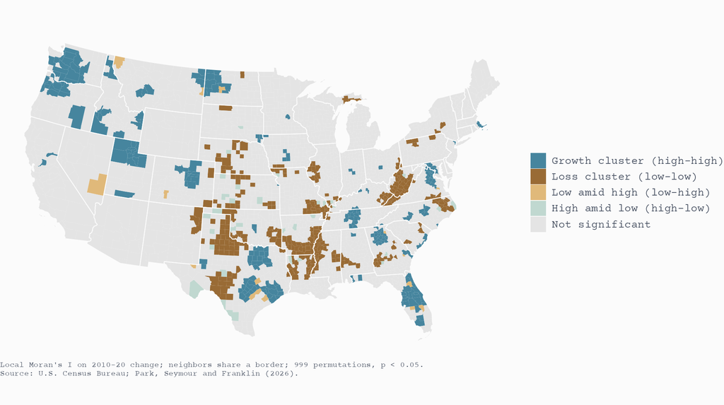

Local Moran’s I of population change, US counties, 2010–2020

## Fragmentation

An alternative way of understanding the configuration of loss within an area, borrowing from ecological habitat fragmentation

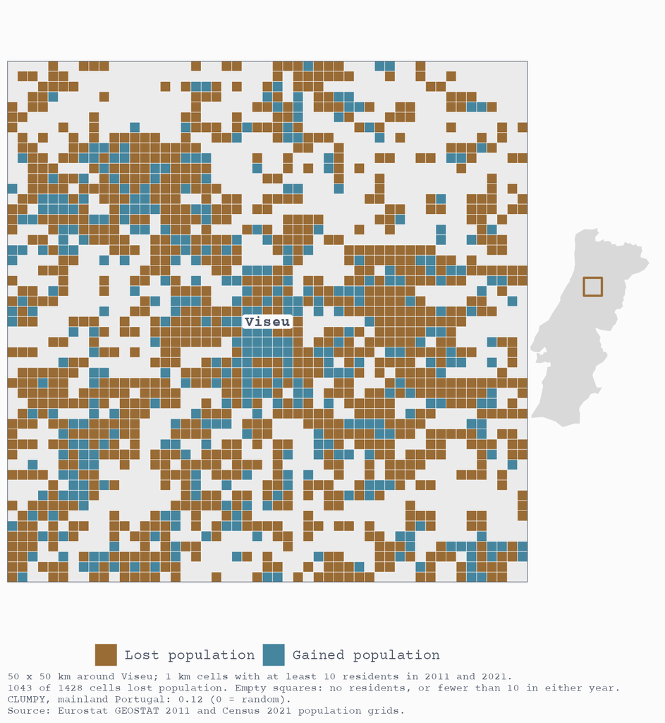

Fragmentation of population loss at 1 km, central Portugal, 2011–2021

## Centrality / Peripherality

Especially in an urban context, one question is the extent to which loss is happening in the core or edges of the city (or in between)

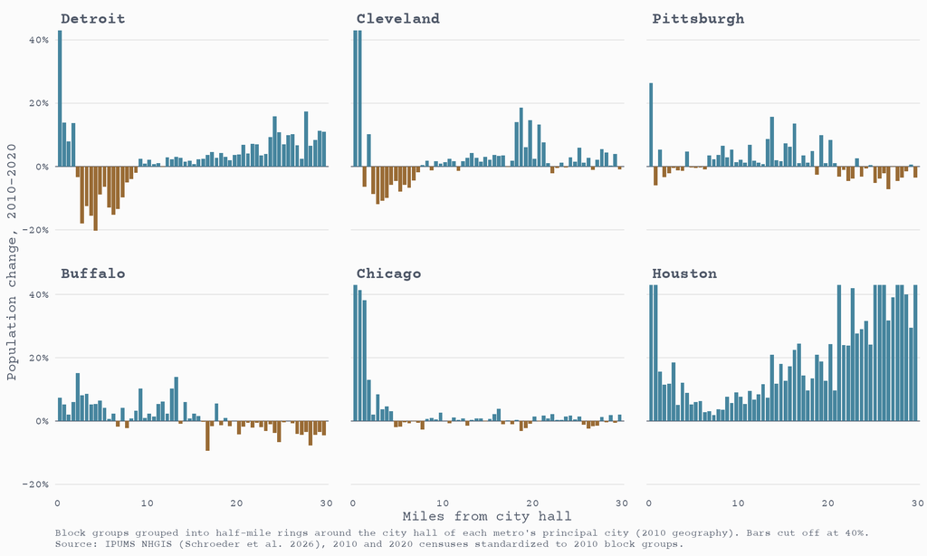

Population change by distance from city hall, 2010–2020

## Urban-rural continuum

In a national or regional context, where is loss occurring? Is it a remote rural issue, an urban issue?

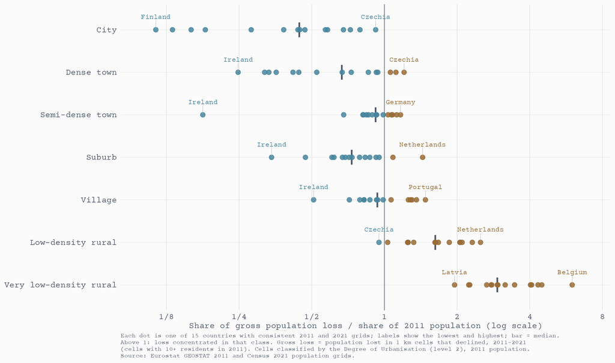

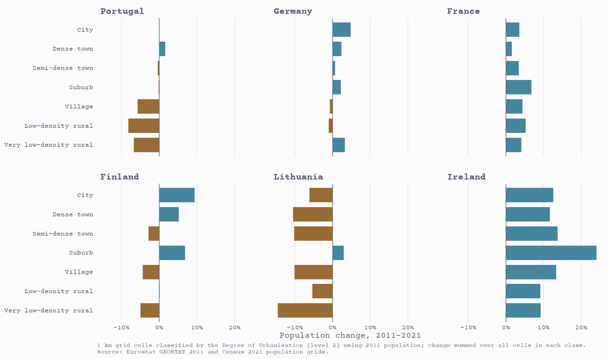

# Closing thoughts

Where does this leave us?

## Some aspects of depopulation are probably here to stay

- Aging
- Below-replacement level fertility
- Housing challenges that don’t evaporate with decline
- Transport demand that might not, either
- Regional and global interdependence
- Uncertainty

## Different kinds of loss demand different kinds of policy responses

And both demographic and geographic considerations are important

## Demographic

- Helping individuals reach desired family size
- The role of immigration policy

## Geographic (place-based policy)

- It helps to know: How extensive is loss? Where is it happening and how scale-dependent is it? Where in the area is it occurring and are all sub-areas equally affected?

## Geographic (place-based policy)

- Helping individuals reach desired residential location (staying, going…)
- Balancing challenges of growth and loss within the same national context

# The End.

Thank you!!